# Evanston Food Insec Model Dev

Adi Tyagi

8/18/2020

## Load libraries and obtain data

We begin modelling with the Evanston only data.

```r
library(tidyverse)
```

```r
library(ggplot2)
library(car)
##################MODEL WITH THE EVANSTON ONLY NOW############
fa_pm_evanston = read_csv("../Data/Modelling Data/fa_pm_evanston-model.csv")
```

## Model Building

We can do so by iterate through variables in list. They are in descending order of correlation with food_insecurity_num_2020. At each step, we add a variable from the list and compute the adjusted r-sq. In the end, we pick the variable subset with the highest adj r-sq.

```r
var_list = c( 'median_household_income',
'median_age', 'social_vulnerability_index',
'median_home_loan_amount', 'median_home_value', 'prop_nonwhite',
'prop_nonenglish_speaking', 'proportion_hispanic',
'thiel_racial_segregation_index', 'proportion_bachelors_degree',
'computer_access', 'prop_families_poverty', 'num_jobs',
'num_housing_units', 'life_expectancy', 'avg_travel_time_to_work',
'prop_students_in_public_school', 'median_leverage_ratio',
'proportion_disabled', 'avg_household_size', 'prop_men',
'local_census_tract', 'unemployment_change')

mod_set = c("food_insecurity_num_2018")
results = data.frame(index = c(), adj_rsq = c())
i = 0
for (var in var_list) {
  mod_set = append(mod_set, var)
  i = i + 1
  lin.mod = lm(log(food_insecurity_num_2018) ~ .,
               data = fa_pm_evanston %>% select(mod_set))
  adj_rsq = summary(lin.mod)$adj.r.squared
  results = rbind(results, list(i, adj_rsq))
}
names(results)[1] = "variable_index"
names(results)[2] = "adj-rsq"
results
```

|  | variable_index | adj-rsq |
| --- | --- | --- |
| 1 | 1 | 0.7075563 |
| 2 | 2 | 0.7497258 |
| 3 | 3 | 0.8295988 |
| 4 | 4 | 0.8252815 |
| 5 | 5 | 0.8208603 |
| 6 | 6 | 0.8730529 |
| 7 | 7 | 0.8679664 |
| 8 | 8 | 0.8579622 |
| 9 | 9 | 0.8553101 |
| 10 | 10 | 0.8407298 |

[output cut: 13 more lines]

Let’s graph the results

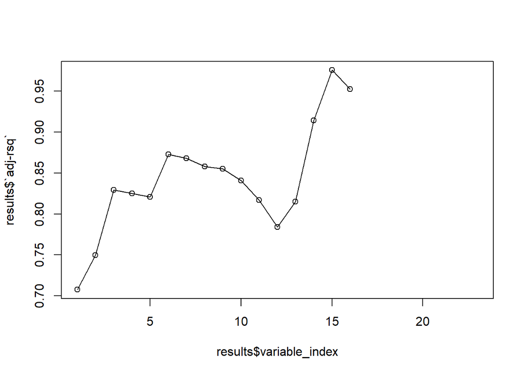

```r
#results %>% ggplot() + geom_point(aes(x = variable_index, y = adj_rsq))
plot(results$variable_index, results$`adj-rsq`, type = 'o')
```

### Initial Subset

The variable subset with the highest adj-rsq has been identified as: - median_household_income - median_age - social_vulnerabillity_index - median_home_loan_amount - median_home_value - prop_nonwhite - prop_nonenglish_speaking - proportion_hispanic - thiel_racial_segregation_index - proportion_bachelors_degree - computer_access - prop_families_poverty - num_jobs - num_housing_units - life_expectancy

These are the first 15 variables, as identified by the peak in the graph above.

```r
vars_list.subset = c( 'median_household_income',
                      'median_age', 'social_vulnerability_index',
                      'median_home_loan_amount', 'median_home_value', 'prop_nonwhite',
                      'prop_nonenglish_speaking', 'proportion_hispanic',
                      'thiel_racial_segregation_index', 'proportion_bachelors_degree',
                      'computer_access', 'prop_families_poverty', 'num_jobs',
                      'num_housing_units', 'life_expectancy', 'food_insecurity_num_2018')
mod.evanston.subset1 = lm(log(food_insecurity_num_2018) ~.,
                        data = fa_pm_evanston %>% select(vars_list.subset))
summary(mod.evanston.subset1)
```

```
##
## Call:
## lm(formula = log(food_insecurity_num_2018) ~ ., data = fa_pm_evanston %>%
##     select(vars_list.subset))
##
## Residuals:
##         1         2         3         4         5         6         7
## -0.003349  0.025756 -0.057298 -0.016589  0.044254 -0.011994 -0.011353
##         8         9        10        11        12        13        14
## -0.025494  0.029653  0.032157  0.018626  0.026459 -0.016408  0.031594
##        15        16        17        18
## -0.014030  0.012348 -0.014504 -0.049827
##
## Coefficients:
##                                  Estimate Std. Error t value Pr(>|t|)
## (Intercept)                    -7.104e-01  2.125e+00  -0.334   0.7700
## median_household_income         7.534e-06  2.337e-06   3.224   0.0843 .
## median_age                     -8.536e-02  1.103e-02  -7.738   0.0163 *
## social_vulnerability_index      2.644e+00  4.821e-01   5.484   0.0317 *
## median_home_loan_amount         3.693e-06  1.051e-06   3.515   0.0723 .
## median_home_value              -1.391e-06  6.282e-07  -2.214   0.1573
## prop_nonwhite                   1.563e-02  7.792e-03   2.005   0.1828
## prop_nonenglish_speaking       -1.025e-02  1.275e-02  -0.804   0.5058
## proportion_hispanic             4.544e-02  1.092e-02   4.162   0.0532 .
## thiel_racial_segregation_index -3.081e+00  8.377e-01  -3.678   0.0666 .
## proportion_bachelors_degree     9.457e-02  1.866e-02   5.068   0.0368 *
## computer_access                -1.237e-02  1.197e-02  -1.034   0.4098
## prop_families_poverty          -1.639e-02  1.309e-02  -1.252   0.3371
## num_jobs                       -1.139e-04  2.756e-05  -4.131   0.0539 .
## num_housing_units               1.479e-04  5.179e-05   2.856   0.1038
## life_expectancy                 6.986e-02  2.380e-02   2.936   0.0991 .
## ---
## Signif. codes:  0 '***' 0.001 '**' 0.01 '*' 0.05 '.' 0.1 ' ' 1
##
## Residual standard error: 0.08481 on 2 degrees of freedom
## Multiple R-squared:  0.9971, Adjusted R-squared:  0.9757
## F-statistic: 46.59 on 15 and 2 DF,  p-value: 0.0212
```

### Subset 2

We now retry the model with another subset, which is smaller and has only significant variables.

```r
mod.evanston.subset2 = lm(log(food_insecurity_num_2018) ~
                          median_household_income +
                          median_age +
                          social_vulnerability_index +
                          median_home_loan_amount +
                          proportion_hispanic +
                          thiel_racial_segregation_index +
                          proportion_bachelors_degree  +
                          num_jobs +
                          life_expectancy,
                        data = fa_pm_evanston)
summary(mod.evanston.subset2)
```

```
##
## Call:
## lm(formula = log(food_insecurity_num_2018) ~ median_household_income +
##     median_age + social_vulnerability_index + median_home_loan_amount +
##     proportion_hispanic + thiel_racial_segregation_index + proportion_bachelors_degree +
##     num_jobs + life_expectancy, data = fa_pm_evanston)
##
## Residuals:
##      Min       1Q   Median       3Q      Max
## -0.19685 -0.11698  0.03691  0.10336  0.15751
##
## Coefficients:
##                                  Estimate Std. Error t value Pr(>|t|)
## (Intercept)                     2.134e+00  2.065e+00   1.034  0.33154
## median_household_income         1.486e-06  3.298e-06   0.451  0.66422
## median_age                     -6.671e-02  1.850e-02  -3.606  0.00692 **
## social_vulnerability_index      2.247e+00  4.692e-01   4.789  0.00137 **
## median_home_loan_amount         5.485e-07  8.293e-07   0.661  0.52694
## proportion_hispanic             3.519e-02  1.532e-02   2.297  0.05069 .
## thiel_racial_segregation_index -2.061e+00  7.984e-01  -2.581  0.03256 *
## proportion_bachelors_degree     6.075e-02  2.212e-02   2.746  0.02520 *
## num_jobs                       -8.011e-05  2.973e-05  -2.695  0.02731 *
## life_expectancy                 4.245e-02  2.305e-02   1.842  0.10273
## ---
## Signif. codes:  0 '***' 0.001 '**' 0.01 '*' 0.05 '.' 0.1 ' ' 1
##
## Residual standard error: 0.169 on 8 degrees of freedom
## Multiple R-squared:  0.9547, Adjusted R-squared:  0.9037
## F-statistic: 18.72 on 9 and 8 DF,  p-value: 0.0001866
```

### Subset 3

We can remove more variables that were not significant, and rebuild a smaller more parsimonious model.

```r
mod.evanston.subset3 = lm(log(food_insecurity_num_2018) ~
                            median_age +
                            social_vulnerability_index +
                          proportion_hispanic +
                          thiel_racial_segregation_index +
                          proportion_bachelors_degree  +
                          num_jobs,
                          data = fa_pm_evanston)
summary(mod.evanston.subset3)
```

```
##
## Call:
## lm(formula = log(food_insecurity_num_2018) ~ median_age + social_vulnerability_index +
##     proportion_hispanic + thiel_racial_segregation_index + proportion_bachelors_degree +
##     num_jobs, data = fa_pm_evanston)
##
## Residuals:
##      Min       1Q   Median       3Q      Max
## -0.29360 -0.07983  0.01475  0.10135  0.20990
##
## Coefficients:
##                                  Estimate Std. Error t value Pr(>|t|)
## (Intercept)                     5.904e+00  6.472e-01   9.123 1.83e-06 ***
## median_age                     -4.725e-02  1.093e-02  -4.324 0.001206 **
## social_vulnerability_index      1.810e+00  3.650e-01   4.960 0.000429 ***
## proportion_hispanic             1.947e-02  1.169e-02   1.666 0.123976
## thiel_racial_segregation_index -1.645e+00  7.193e-01  -2.287 0.042973 *
## proportion_bachelors_degree     4.043e-02  1.944e-02   2.079 0.061786 .
## num_jobs                       -4.060e-05  1.798e-05  -2.258 0.045281 *
## ---
## Signif. codes:  0 '***' 0.001 '**' 0.01 '*' 0.05 '.' 0.1 ' ' 1
##
## Residual standard error: 0.1745 on 11 degrees of freedom
## Multiple R-squared:  0.9336, Adjusted R-squared:  0.8973
## F-statistic: 25.76 on 6 and 11 DF,  p-value: 7.245e-06
```

### Subset 4

We now remove prop_hispanic that was not significant (pvalue = 0.12, and rebuild a smaller more parsimonious model. This shall be our final model.

```r
mod.evanston.subset4 = lm(log(food_insecurity_num_2018) ~
                            median_age +
                            social_vulnerability_index +
                          thiel_racial_segregation_index +
                          proportion_bachelors_degree  +
                          num_jobs,
                          data = fa_pm_evanston)
summary(mod.evanston.subset4)
```

```
##
## Call:
## lm(formula = log(food_insecurity_num_2018) ~ median_age + social_vulnerability_index +
##     thiel_racial_segregation_index + proportion_bachelors_degree +
##     num_jobs, data = fa_pm_evanston)
##
## Residuals:
##      Min       1Q   Median       3Q      Max
## -0.30023 -0.07864  0.02958  0.10355  0.24332
##
## Coefficients:
##                                  Estimate Std. Error t value Pr(>|t|)
## (Intercept)                     6.498e+00  5.789e-01  11.225 1.01e-07 ***
## median_age                     -4.179e-02  1.117e-02  -3.742 0.002812 **
## social_vulnerability_index      1.972e+00  3.770e-01   5.229 0.000211 ***
## thiel_racial_segregation_index -1.844e+00  7.600e-01  -2.427 0.031904 *
## proportion_bachelors_degree     1.870e-02  1.545e-02   1.211 0.249373
## num_jobs                       -3.128e-05  1.831e-05  -1.708 0.113301
## ---
## Signif. codes:  0 '***' 0.001 '**' 0.01 '*' 0.05 '.' 0.1 ' ' 1
##
## Residual standard error: 0.1869 on 12 degrees of freedom
## Multiple R-squared:  0.9168, Adjusted R-squared:  0.8821
## F-statistic: 26.45 on 5 and 12 DF,  p-value: 4.351e-06
```

## Subset 5

We now remove proportion bachelor’s degrees and num jobs since they were not significant in the previous model.

```r
mod.evanston.subset4 = lm(log(food_insecurity_num_2018) ~
                            median_age +
                            social_vulnerability_index +
                          thiel_racial_segregation_index,
                          data = fa_pm_evanston)
summary(mod.evanston.subset4)
```

```
##
## Call:
## lm(formula = log(food_insecurity_num_2018) ~ median_age + social_vulnerability_index +
##     thiel_racial_segregation_index, data = fa_pm_evanston)
##
## Residuals:
##      Min       1Q   Median       3Q      Max
## -0.31017 -0.12795  0.00253  0.07803  0.34434
##
## Coefficients:
##                                 Estimate Std. Error t value Pr(>|t|)
## (Intercept)                     6.661592   0.328909  20.254 9.06e-12 ***
## median_age                     -0.029944   0.009087  -3.295  0.00531 **
## social_vulnerability_index      1.682515   0.264639   6.358 1.78e-05 ***
## thiel_racial_segregation_index -2.086758   0.748781  -2.787  0.01455 *
## ---
## Signif. codes:  0 '***' 0.001 '**' 0.01 '*' 0.05 '.' 0.1 ' ' 1
##
## Residual standard error: 0.1934 on 14 degrees of freedom
## Multiple R-squared:  0.8961, Adjusted R-squared:  0.8739
## F-statistic: 40.27 on 3 and 14 DF,  p-value: 3.903e-07
```

## Multicollinearity check

As a final check, let’s see if there is multicollinearity present in our data by calculating the VIFs (Variance Inflation Factor). A VIF greater than 10 would indicate that we have multicollinearity present in our model.

```r
vif(mod.evanston.subset4)
```

```
##                     median_age     social_vulnerability_index
##                       1.927718                       1.356918
## thiel_racial_segregation_index
##                       1.790253
```

The vif’s are quite small (below the threshold of 10), indicating that we don’t have multicollinearity in our model. Yay!

## Key Takeaways from using log(2018_food_insecurity_num) as the dependent variable

Three variables cumulatively account for ~90% of variation in the dependent variable.

- median age: negative effect
- social vulnerability index: positive effect
- thiel racial segregation index: negative effect

### Compare and contrast with the 2020 model

Overall, our 2018 model has a slightly worse fit (0.8739 adj rsq vs. 0.9338 adj rsq for the 2020 model). The 2018 model has fewer variables (3 vs 6 for the 2020 model) Finally, the 2018 model narrows the subset of variables used in the 2020 model. In particular, the 2018 model excludes:

- median household income
- median home value
- num housing units

all of which were included in the 2020 model.

## Key Takeaways from using the 2020_food_insecurity_num as the dependent variable

In the end, we have created a 6 variable model with a 0.9338 adj. r-squared. A positive effect indicates that higher values of the variable are associated with higher values of food insecurity; A negative effect indicates that lower values of the variable are associated with higher varlues of food insecurity.

Overall, the takeaways are the following:

- median_household_income: positive effect
- median_age: negative effect
- social_vulnerability_index: positive effect
- median_home_value: negative effect
- thiel_racial_segregation_index: negative effect
- num_housing_units: positive effect

## Feedback received on 8/14:

- log the dependent variable - (AT)
- How is racial segregation being measured? (Thiel Racial Seg) - MS
- VIF seems good? - AW
- Hypothesis Test between top_n and bottom_n- AW
- Work with cooler variable selection methods (FFS, BFS, hclust,) - DC
- Use 2018 food insecurity num as your dependent variable - AT